# Part 1 - ASA Short Course Second-generation p-values (Half-Day)

# Introduction

- Jeffrey D. Blume, PhD
  - School of Data Science, University of Virginia
- Megan H. Murray, PhD
  - Department of Biostatistics, Vanderbilt University

Resources:

- GitHub with Slides and Code: www.github.com/murraymegan/SGPV-ASA-Short-Course-2022
- RStudio Desktop: www.rstudio.com/products/rstudio/download
- Interrupt or use Zoom chat for questions!

# SGPV R Package

There are 2 ways to install `sgpv` package.

- CRAN: `install.packages("sgpv")`
- GitHub: `devtools::install_github("weltybiostat/sgpv")`

```r
#GitHub
install.packages("devtools")
devtools::install_github("weltybiostat/sgpv")

#CRAN
install.packages("sgpv")
```

Functions Included:

- `sgpvalue()`
  - This function computes the second-generation p-value (SGPV) and its associated delta gaps, as introduced in Blume et al. (2018).
- `sgpower()`
  - Calculate power and type I error values from significance testing based on second-generation p-values as the inferential metric.
- `plotsgpv()`
  - This function displays user supplied interval estimates (support intervals, confidence intervals, credible intervals, etc.) according to its associated second-generation p-value ranking.
- `plotman()`
  - This function displays a modified Manhattan-style plot colored according to second-generation p-value status.
- `fdrisk()`
  - This function computes the false discovery risk (sometimes called the “empirical bayes FDR”) for a second-generation p-value of 0, or the false confirmation risk for a second-generation p-value of 1.

# 1 Part 1

## 1.1 COVID Clinical Trial

- Randomized 1,591 patients to ivermectin treatment or placebo
- Mean time spent unwell was estimated using a longitudinal ordinal regression model; range was 0 to 14 days
- Patients reported each day their symptoms and severity, health care visits, and medications.
- “The difference in the amount of time spent feeling unwell with COVID was estimated to be 0.49 days in favor of ivermectin with a 95% credible interval of (0.15, 0.82).”
- [Link to Preprint](https://www.medrxiv.org/content/10.1101/2022.06.10.22276252v1)

```r
#Setup
theta0 = 0
point = 0.49
data.lo = 0.15
data.hi = 0.82
```

#### 3 hours difference

```r
sgpvalue(est.lo = data.lo,
         est.hi = data.hi,
         null.lo = -0.125,
         null.hi = 0.125)
```

```
## $p.delta
## [1] 0
##
## $delta.gap
## [1] 0.2
```

#### 5 hours difference

```r
sgpvalue(est.lo = data.lo,
         est.hi = data.hi,
         null.lo = -0.2083,
         null.hi = 0.2083)
```

```
## $p.delta
## [1] 0.08701493
##
## $delta.gap
## [1] NA
```

#### 6 hours difference

```r
sgpvalue(est.lo = data.lo,
         est.hi = data.hi,
         null.lo = -0.25,
         null.hi = 0.25)
```

```
## $p.delta
## [1] 0.1492537
##
## $delta.gap
## [1] NA
```

#### 12 hours difference

```r
sgpvalue(est.lo =data.lo,
         est.hi = data.hi,
         null.lo = -0.5,
         null.hi = 0.5)
```

```
## $p.delta
## [1] 0.5223881
##
## $delta.gap
## [1] NA
```

#### 18 hours difference

```r
sgpvalue(est.lo = data.lo,
         est.hi = data.hi,
         null.lo = -0.75,
         null.hi = 0.75)
```

```
## $p.delta
## [1] 0.8955224
##
## $delta.gap
## [1] NA
```

#### 1 day difference

```r
sgpvalue(est.lo = data.lo,
         est.hi = data.hi,
         null.lo = -1,
         null.hi = 1)
```

```
## $p.delta
## [1] 1
##
## $delta.gap
## [1] NA
```

## 1.2 Systolic Blood Pressure

- SBP is reported to the nearest 2 mmHg
- Null Hypothesis: mean SPB is 146 mmHg
- Interval Null hypothesis: mean is 144 to 148 mmHg
- Results from 8 mock studies

```r
#SBP Example Background

# Data means
xbar=c(141,142,143.5,144,146,145,145.5,146)

# Data Standard Errors
se=c(.5,1,.5,1,2.25,1.25,.25,.5)

# Indifference Zone
delta.a=144
delta.b=148

#Point Null
h0=146

# Estimated Uncertainty Interval Bounds
lb<-xbar-1.96*se
ub<-xbar+1.96*se
```

```r
sgpvalue(est.lo=lb,
               est.hi=ub,
               null.lo = delta.a,
               null.hi = delta.b)
```

```
## $p.delta
## [1] 0.0000000 0.0000000 0.2448980 0.5000000 0.5000000 0.7040816 1.0000000
## [8] 1.0000000
##
## $delta.gap
## [1] 1.01 0.02   NA   NA   NA   NA   NA   NA
```

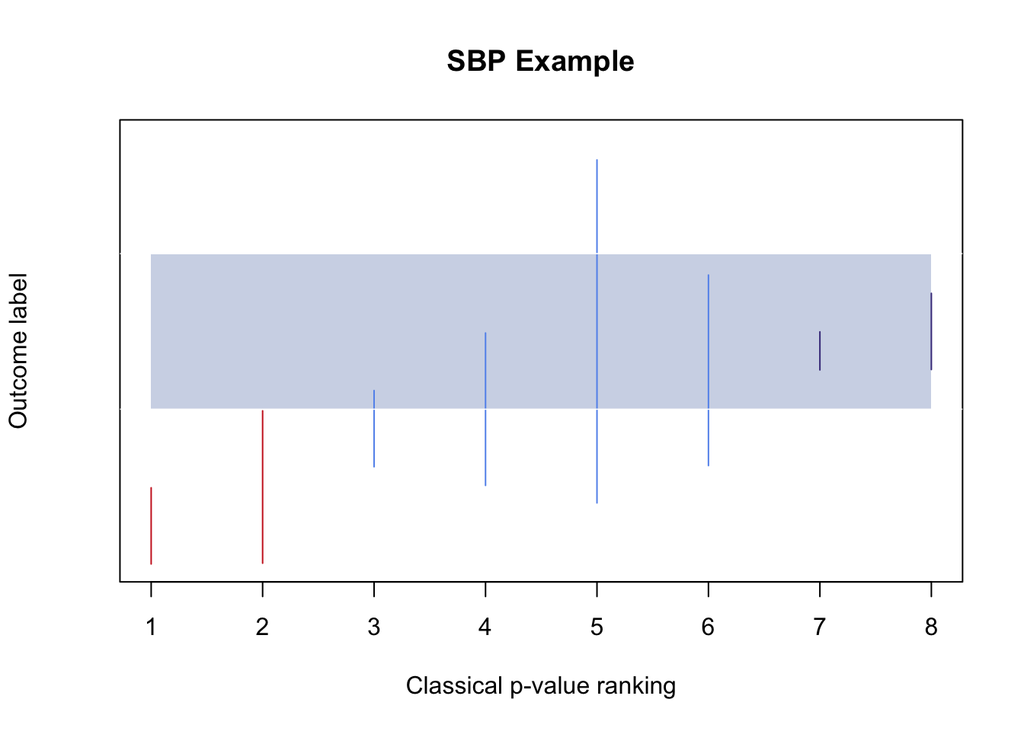

```r
plotsgpv(est.lo = lb,
         est.hi = ub,
         null.lo = delta.a,
         null.hi = delta.b,
            plot.axis=c("TRUE","FALSE"),
            null.pt=0, outline.zone=TRUE,
            title.lab="SBP Example",
            x.lab="Classical p-value ranking",
            legend.on=FALSE)
```

```r
# sgpower(true=xbar,
#         null.lo=delta.a,
#         null.hi=delta.b,
#         std.err=se,
#         interval.type='confidence',
#         'interval.level'=0.05)
```

```r
# Raw p-value Z-value
z1<-(xbar-h0)/se

# Max p-value Z-value
z2<-ifelse(abs(xbar-delta.b)< abs(xbar-delta.a),(xbar-delta.b)/se,(xbar-delta.a)/se)
z2<-ifelse(xbar>delta.b | delta.a > xbar,z2,0)

# Raw p-value
p1 <- round(2*pnorm(-abs(z1)),4)

# Max p-value
p2 <- round(2*pnorm(-abs(z2)),4)

#SGPV
p3 <- sgpvalue(est.lo=lb,
               est.hi=ub,
               null.lo = delta.a,
               null.hi = delta.b)$p.delta
```

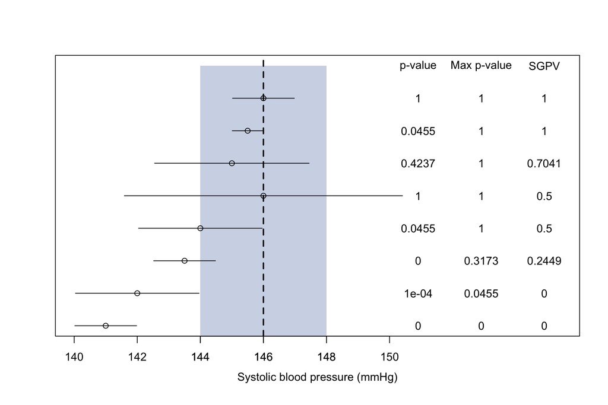

```r
## Plot of SBP example
id.color=rgb(208,216,232,max=255)

plot(c(xbar,NA),1:(length(xbar)+1),xlim=c(min(lb,delta.a),max(ub)+5),xaxt='n',yaxt='n',ylab="",xlab="",type="n")
    rect(delta.a,length(xbar)+1,delta.b,0,col=id.color,border=NA)

abline(v=h0,lty=2,lwd=2,col='black')
points(c(xbar,NA),1:(length(xbar)+1))

for(i in 1:8){
  lines(c(lb[i],ub[i]),c(i,i))
}

text(max(ub)+4.5,1:(length(xbar)+1),c(round(p3,4),"SGPV"))
text(max(ub)+2.5,1:(length(xbar)+1),c(round(p2,4),"Max p-value"))
text(max(ub)+.5,1:(length(xbar)+1),c(round(p1,4),"p-value"))

axis(side = 1,at=seq(round(min(lb)),round(max(ub)),delta.b-h0))
axis(side=1,at=seq(144,148,2))  # to re-draw axis
mtext(side=1,"Systolic blood pressure (mmHg)",line=2.5)
```

## 1.3 BOMAMI

- European Heart Journal (2011): https://academic.oup.com/eurheartj/article/32/14/1748/527618
- Randomized multicenter study
- Intracoronary administration of autologous bone marrow cells (BMCs) can lead to a modest improvement in cardiac function
- Aim: Evaluate the effect of BMC therapy on myocardial viability in patients with decreased left ventricular ejection fraction (LVEF) after acute myocardial infarction (AMI)
- Null Interval for Odds Ratio and Risk Ratio: (0.9, 1.11)

#### Odds Ratio

```r
###### BOMAMI Trial Slide 28 and 29

## OR
sgpvalue(est.lo=0.967,
         est.hi=7.286,
         null.lo=0.9,
         null.hi=1.11)$p.delta
```

```
## [1] 0.3404762
```

#### Logistic Regression with Null Zone: (0.9, 1.11)

```r
## Logistic Regression Slide 30
###### BOMAMI Trial

## Primary OR
p1 = sgpvalue(est.lo=1.18,
              est.hi=20.19,
              null.lo=0.9,
              null.hi=1.11)$p.delta

## Covariates
p2 = sgpvalue(est.lo=1.09,
              est.hi=19.28,
              null.lo=0.9,
              null.hi=1.11)$p.delta
p3 = sgpvalue(est.lo=0.86,
              est.hi=38.29,
              null.lo=0.9,
              null.hi=1.11)$p.delta
p4 = sgpvalue(est.lo=0.66,
              est.hi=8.98,
              null.lo=0.9,
              null.hi=1.11)$p.delta
p5 = sgpvalue(est.lo=0.36,
              est.hi=26.92,
              null.lo=0.9,
              null.hi=1.11)$p.delta
p6 = sgpvalue(est.lo=0.95,
              est.hi=1.11,
              null.lo=0.9,
              null.hi=1.11)$p.delta
p7 = sgpvalue(est.lo=0.09,
              est.hi=1.59,
              null.lo=0.9,
              null.hi=1.11)$p.delta
```

```r
# Table with results
kable(cbind(c("Variable",
              "group",
              "tobacco",
              "microvascular obstroction",
              "dyslipidemia",
              "gender",
              "age",
              "hypertension"),
            c("Odds Ratio", 4.89,4.59,5.72,2.32,3.12,1.02,0.38),
            c("Raw p-value", 0.03,0.04,0.07,0.22,0.30,0.56,0.19),
            c("SGPV",p1,round(p2,3),p3,p4,p5,p6,p7)), format = "html", table.attr = "style='width:50%;'") %>%
  kable_styling(c("striped", "bordered"))
```

| Variable | Odds Ratio | Raw p-value | SGPV |
| --- | --- | --- | --- |
| group | 4.89 | 0.03 | 0 |
| tobacco | 4.59 | 0.04 | 0.048 |
| microvascular obstroction | 5.72 | 0.07 | 0.5 |
| dyslipidemia | 2.32 | 0.22 | 0.5 |
| gender | 3.12 | 0.3 | 0.5 |
| age | 1.02 | 0.56 | 1 |
| hypertension | 0.38 | 0.19 | 0.5 |

## 1.4 Lung Cancer Survival

- Survival time in patients with advanced lung cancer (days)
- Potential for gender dissimilarities
- Trial by North Central Cancer Treatment Group (1994): https://pubmed.ncbi.nlm.nih.gov/8120560/
- Interval Null [-0.05, 0.05] % difference

```r
# Survival Model stratified females and Males
fit<- survfit(Surv(time, status) ~ sex, data = lung)
# plot(fit,col=c("red","blue"))
# summary(fit)
# objects(fit)
# summary(fit)$surv

newdata=lung$sex

lung.Surv <- with(lung, Surv(time=time, event=status))
lung.survfit <- survfit(lung.Surv ~ lung$sex)

sCox <- coxph(lung.Surv ~ as.factor(sex),data=lung)
```

```r
#Compute SGPV of difference
pred.1=summary(survfit(sCox,newdata=data.frame(sex=1)))$surv
pred.2=summary(survfit(sCox,newdata=data.frame(sex=2)))$surv

pred.diff=pred.2-pred.1

time.diff=summary(survfit(sCox,newdata=data.frame(sex=1)))$time

v.1=summary(survfit(sCox,newdata=data.frame(sex=1)))$std.err^2
v.2=summary(survfit(sCox,newdata=data.frame(sex=2)))$std.err^2

se.diff=sqrt(v.1+v.2)

lb=pred.diff-1.96*se.diff
ub=pred.diff+1.96*se.diff

pdelt <- sgpvalue(lb,ub,-0.05,0.05)$p.delta
```

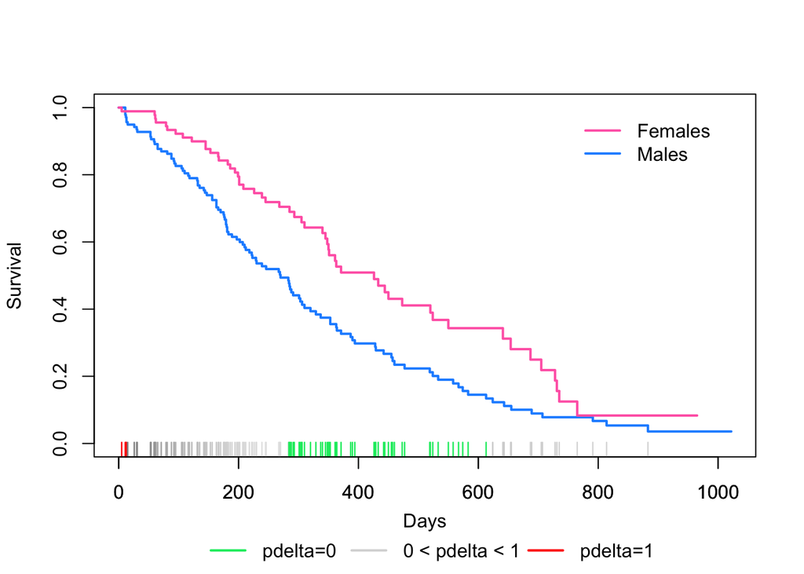

```r
#Survival Plot
plot(lung.survfit,col=c("dodgerblue1","hotpink"),mark.time=F,lwd=c(2,2),
    ylab="Survival",xlab="") ## sex=1 is hotpink
for (i in 1:length(time.diff)){rug(time.diff[i],col=COL[i],lwd=1.2,ticksize=0.04)}
axis(side=1)
mtext("Days",side=1,line=2.25)

legend(750,1,c("Females","Males"),col=c("hotpink","dodgerblue1"),lty=1,lwd=2,bty="n")

par(xpd=TRUE)
legend(125,-0.25,c("pdelta=0","0 < pdelta < 1","pdelta=1"),text.width=c(60,120,150),
        col=c("#00ea6e","#D8D8D8","#ff0000"),lwd=2,lty=1,horiz=TRUE,bty="n")
```

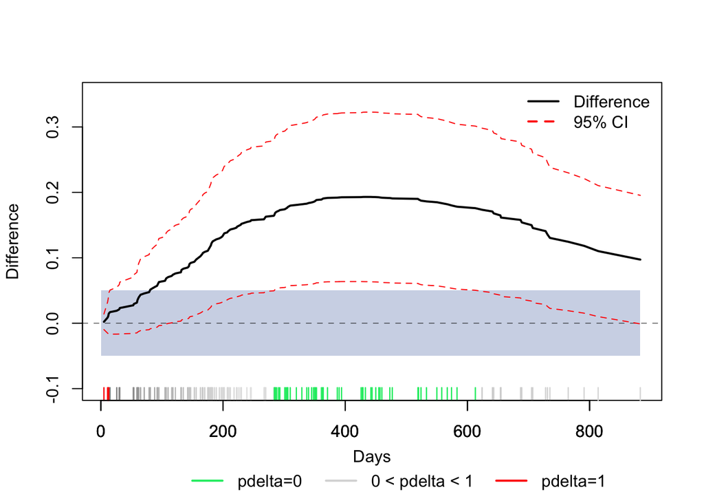

```r
## CI plot of difference
par(xpd=FALSE)
plot(time.diff,pred.diff,ylim=c(-0.1,0.35),xlab="",ylab="Difference",type="n")
axis(side=1)
mtext("Days",side=1,line=2.25)
rect(0,-0.05,max(time.diff),0.05,col=rgb(208,216,232,max=255),border=NA)
lines(time.diff,pred.2-pred.1,lwd=2,col="black")
abline(h=0,lty=2,lwd=0.5)

lines(time.diff,ub,lty=2,col="red")
lines(time.diff,lb,lty=2,col="red")

for (i in 1:length(time.diff)){rug(time.diff[i],col=COL[i],lwd=1.2,ticksize=0.04)}
axis(side=1)
par(xpd=TRUE)
legend(125,-0.21,c("pdelta=0","0 < pdelta < 1","pdelta=1"),text.width=c(60,120,150),
        col=c("#00ea6e","#D8D8D8","#ff0000"),lwd=2,lty=1,horiz=TRUE,bty="n")
par(xpd=FALSE)

legend(675,0.37,c("Difference","95% CI"),col=c("black","red"),lty=c(1,2),lwd=2,bty="n")
```

## 1.5 High Dimensional Data: Leukemia gene expression

- Classifying acute leukemia by precursors (Golub 1999, Science)
- 7128 genes ; 72 patients (47 ALL and 25 AML)
- Goal: Identify `interesting’ genes whose expression levels differ between
- All and AML subjects.
- Looking for fold changes of 2 or more

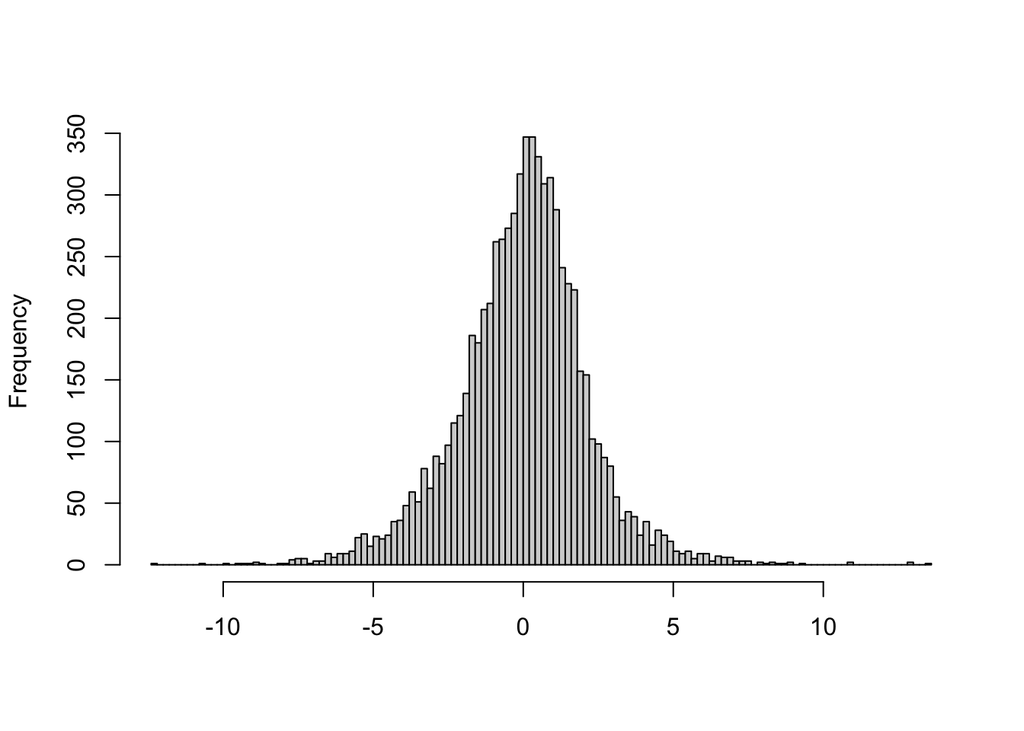

```r
###### Leukemia Example
data(leukstats)

hist(leukstats$t.stat, breaks=100, main="", xlab="")
```

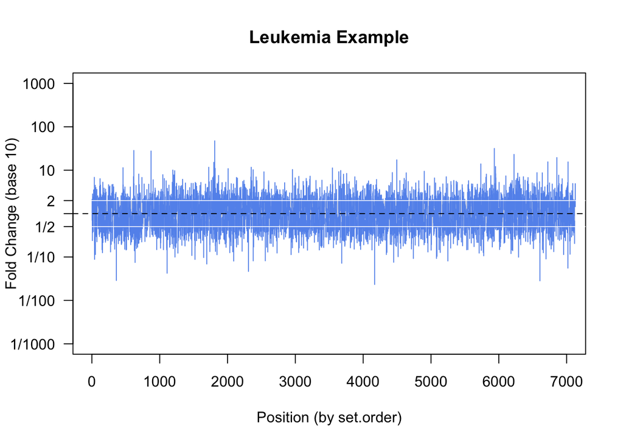

```r
#Plot sgpv no ordering
plotsgpv(est.lo=leukstats$ci.lo, est.hi=leukstats$ci.hi,
        null.lo=-0.3, null.hi=0.3,
        set.order=1:nrow(leukstats),
        x.show=7000,
        plot.axis=c("TRUE","FALSE"),
        int.col="cornflowerblue",
        null.pt=0, outline.zone=TRUE,
        title.lab="Leukemia Example", y.lab="Fold Change (base 10)",
        legend.on=FALSE)
axis(side=2,at=round(log(c(1/1000,1/100,1/10,1/2,1,2,10,100,1000),
    base=10),2),labels=c("1/1000","1/100","1/10","1/2",1,2,10,100,1000),
    las=2)
```

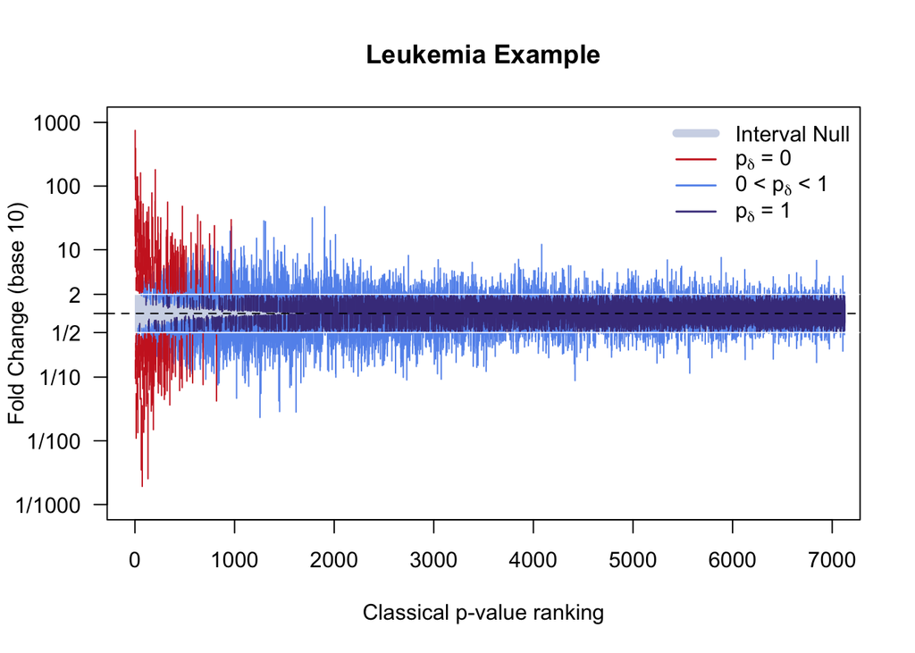

```r
#Plot sgpv with ordering
plotsgpv(est.lo=leukstats$ci.lo, est.hi=leukstats$ci.hi,
        null.lo=-0.3, null.hi=0.3,
        set.order=order(leukstats$p.value),
        x.show=7000,
        plot.axis=c("TRUE","FALSE"),
        null.pt=0, outline.zone=TRUE,
        title.lab="Leukemia Example", y.lab="Fold Change (base 10)",
        x.lab="Classical p-value ranking",
        legend.on=TRUE)
axis(side=2,at=round(log(c(1/1000,1/100,1/10,1/2,1,2,10,100,1000),
    base=10),2),labels=c("1/1000","1/100","1/10","1/2",1,2,10,100,1000),
    las=2)
```

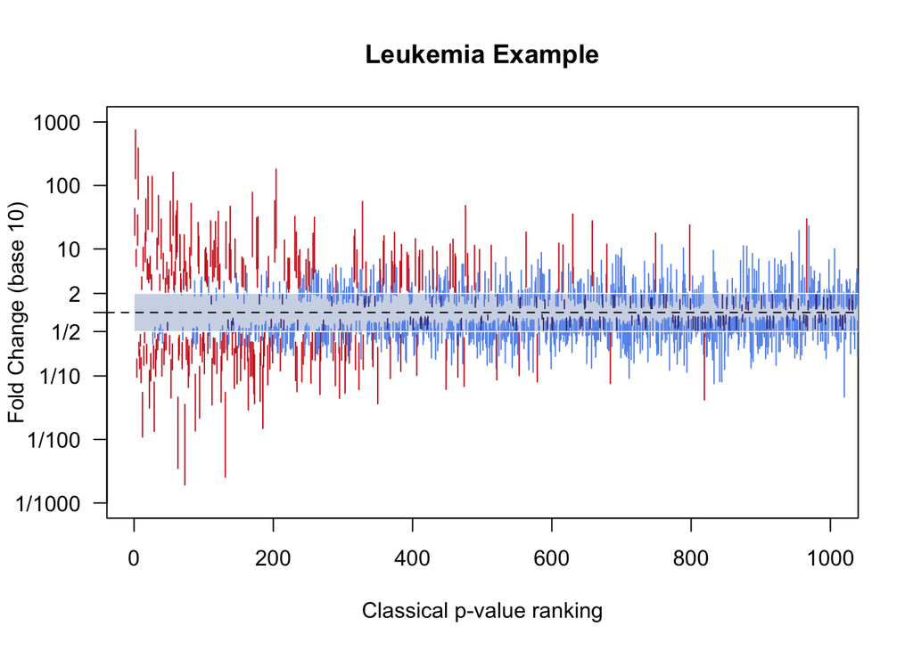

```r
#Plot sgpv with ordering
plotsgpv(est.lo=leukstats$ci.lo, est.hi=leukstats$ci.hi,
        null.lo=-0.3, null.hi=0.3,
        set.order=order(leukstats$p.value),
        x.show=1000,
        plot.axis=c("TRUE","FALSE"),
        null.pt=0, outline.zone=TRUE,
        title.lab="Leukemia Example", y.lab="Fold Change (base 10)",
        x.lab="Classical p-value ranking",
        legend.on=FALSE)
axis(side=2,at=round(log(c(1/1000,1/100,1/10,1/2,1,2,10,100,1000),
    base=10),2),labels=c("1/1000","1/100","1/10","1/2",1,2,10,100,1000),
    las=2)
```

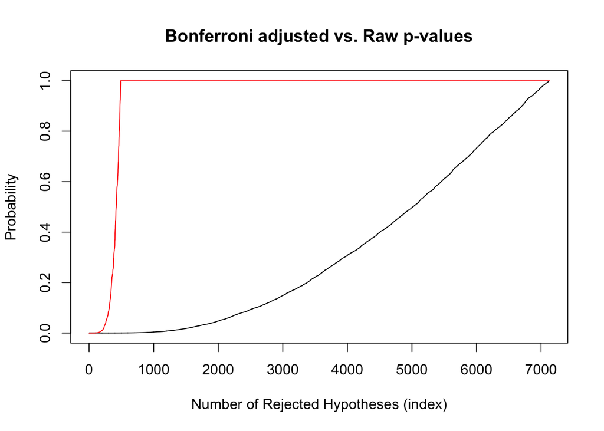

```r
##Bonferroni
res = sgpvalue(est.lo=leukstats$ci.lo, est.hi=leukstats$ci.hi,
        null.lo=-0.3, null.hi=0.3)

plot(c(1:nrow(leukstats)),
     sort(leukstats$p.value),
     ylim=c(0,1),
     type="l",
     main="Bonferroni adjusted vs. Raw p-values",
     ylab="Probability",
     xlab="Number of Rejected Hypotheses (index)")
lines(c(1:nrow(leukstats)), sort(pmin(leukstats$p.value*nrow(leukstats),1)), col="red")
```

- For 1/2 < Fold Change < 2 (Delta = 0.3)

```r
#Table of results

tab.res = table(res$p.delta>0, leukstats$p.value<(0.05/nrow(leukstats)))

colnames(tab.res) = c("SGPV=0", "SGPV>0")
rownames(tab.res) = c("p_Bon>0.05", "p_Bon<0.05")

kable(tab.res)%>%
  kable_styling(c("striped", "bordered"))
```

[output not shown]

## 1.6 Prostate Cancer SNPs

- International Consortium for Prostate Cancer Genetics (Schaid and Chang 2055; ICPCG 2018)
- 3,894 subjects: 2,511 cases & 1,383 controls
- 247,000 single-nucleotide polymorphisms (SNPs) from Chromosome 6
- Goal: Identify interesting SNPs potentially associated with prostate cancer
- https://www.ncbi.nlm.nih.gov/projects/gap/cgi-bin/study.cgi?study_id=phs000733.v1.p1
- Access is controlled so we will simulate data here.

Here we have 10,000 genes with expression from 0 to 4. Patients 0-50 do not cancer and 51-100 do have cancer.

T-tests are conducted for each gene and p-values and CIs are taken from them.

Null Interval: [0.5, 1.3]

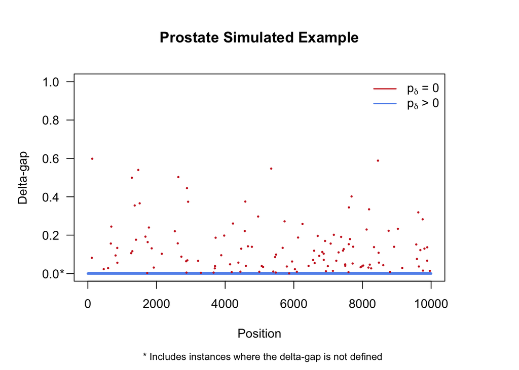

```r
n=10000
pros.sim.data = matrix(NA, nrow=100, ncol=n)
pros.pvalue = NA
pros.lo = NA
pros.hi = NA

for(i in 1:n){
  pros.sim.data[c(1:50),i] = runif(50, 0, 4)
  pros.sim.data[c(51:100),i] = runif(50, 0, 1.5)
  t.res = t.test(pros.sim.data[1:50,i], pros.sim.data[51:100,i])
  pros.pvalue[i] = t.res$p.value
  pros.lo[i] = t.res$conf.int[1]
  pros.hi[i] = t.res$conf.int[2]
}

# Gene number on the x-axis, delta-gap on the y-axis, using an interval null hypothesis of

plotman(est.lo=pros.lo,
        est.hi=pros.hi,
       null.lo=0.5, null.hi=1.3,
       set.order=NA,
       type="delta-gap",
       ref.lines=NA,
       int.pch=16, int.cex=0.4,
       title.lab="Prostate Simulated Example",
       y.lab="Delta-gap",
       x.lab="Position",
       legend.on=TRUE)
```

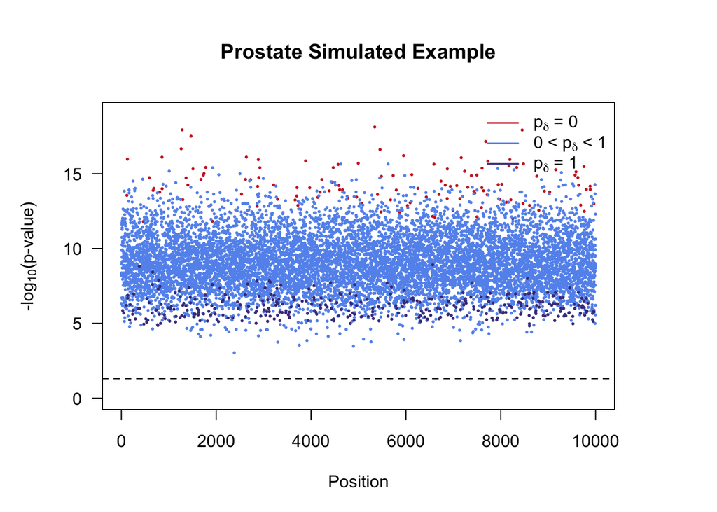

```r
# Gene number on the x-axis, -log10(classical p-value) on the y-axis.

plotman(est.lo=pros.lo,
        est.hi=pros.hi,
       null.lo=0.5, null.hi=1.3,
       set.order=NA,
       type="p-value",
       p.values=-log10(pros.pvalue),
       ref.lines=-log10(0.05),
       int.pch=16, int.cex=0.4,
       title.lab="Prostate Simulated Example",
       y.lab=expression("-log"[10]*"(p-value)"),
       x.lab="Position",
       legend.on=TRUE)
```

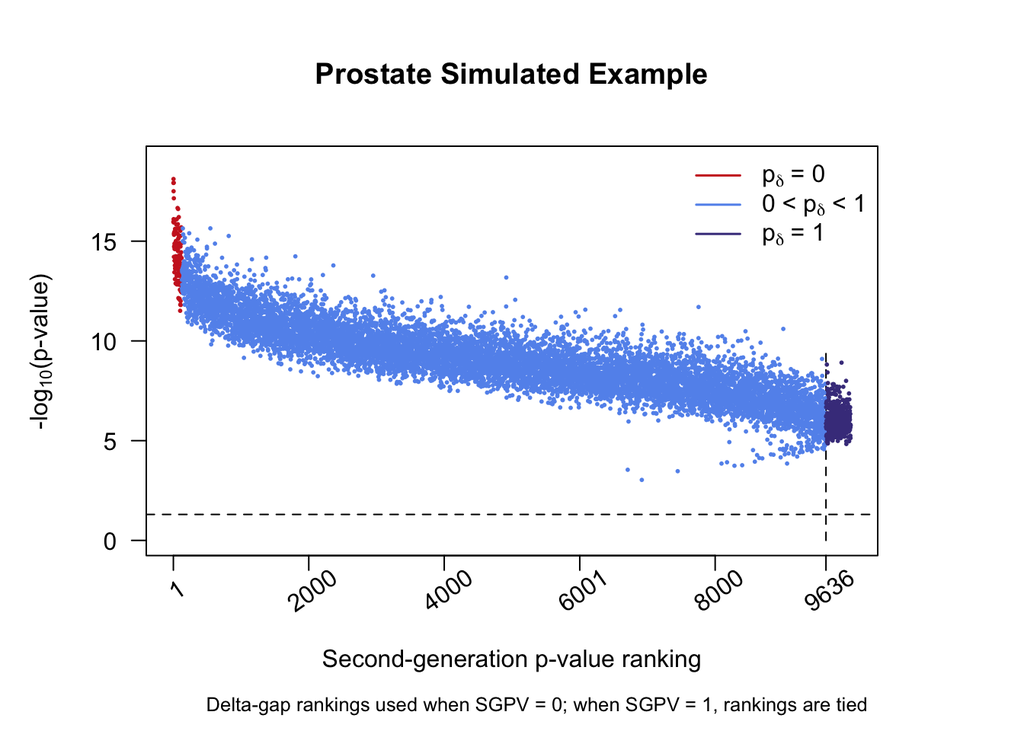

```r
# Second-generation p-value (SGPV) on the x-axis, -log10(classical p-value) on the y-axis

plotman(est.lo=pros.lo,
        est.hi=pros.hi,
       null.lo=0.5, null.hi=1.3,
       set.order="sgpv",
       type="comparison",
       p.values=-log10(pros.pvalue),
       ref.lines=c(-log10(0.05)),
       int.pch=16, int.cex=0.4,
       title.lab="Prostate Simulated Example",
       y.lab=expression("-log"[10]*"(p-value)"),
       x.lab="Second-generation p-value ranking",
       legend.on=TRUE)
```

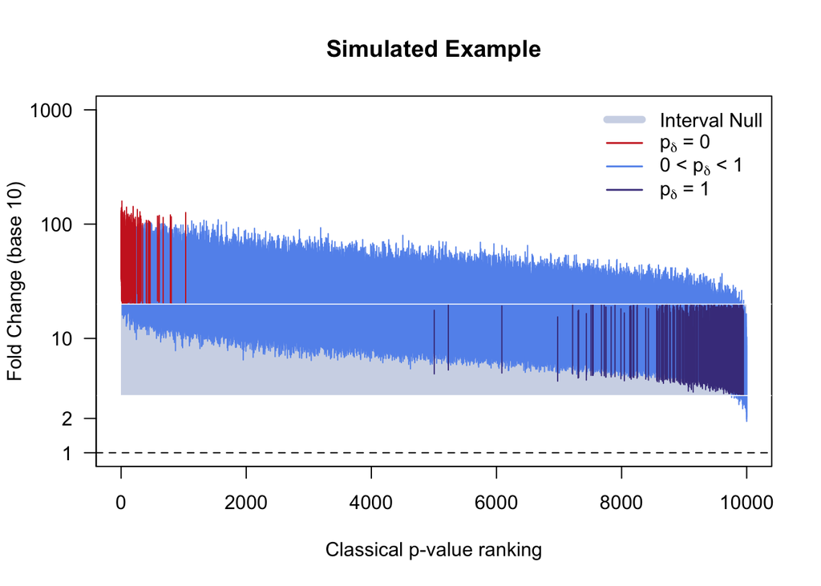

```r
plotsgpv(est.lo=pros.lo,
        est.hi=pros.hi,
       null.lo=0.5, null.hi=1.3,
        set.order=order(pros.pvalue),
        x.show=10000,
        plot.axis=c("TRUE","FALSE"),
        null.pt=0, outline.zone=TRUE,
        title.lab="Simulated Example", y.lab="Fold Change (base 10)",
        x.lab="Classical p-value ranking",
        legend.on=TRUE)
axis(side=2,at=round(log(c(1/1000,1/100,1/10,1/2,1,2,10,100,1000),
    base=10),2),labels=c("1/1000","1/100","1/10","1/2",1,2,10,100,1000),
    las=2)
```